# Chapters 2 and 3 of dissertation

Peter M. Yaworsky

12/16/2020

# Introduction

Welcome to Peter’s dissertation analysis. Here, I walk through the analyses used in my dissertation research. The document primarily exists to help me organize my analyses in a way conducive with troubleshooting problems with my colleagues. Let’s begin by loading the packages.

It is important to note that I do 2 types of analyses here. The first one tests hypotheses derived from the ideal free distribution model about how population expansions and contractions during the Formative period manifested in land-use patterns. The second tests hypotheses about risk sensitivity manifesting in the form of storage feature placement and numbers in the central section of Nine Mile Canyon.

```r
library(MASS)
library(Bchron)
library(mgcv)
library(plotfunctions)
library(rcarbon)
library(sf)
library(raster)
library(rcarbon)
library(funModeling)
#setwd("D:/Desktop/Dissertation")
```

## Hypotheses!

There is an interesting trend with sites across the West Tavaputs Plateau, particularly in Nine Mile Canyon (NMC) and Range Creek (RC). These are where the majority of inventories have taken place and also where the majority of radiocarbon dated material derive, but data also exist in Desolation Canyon. The trend is that the highest density of sites are clustered. I (and others) believe this is likely a result of environmental variables like GDD, which influence maize growth. With the Fremont being maize farmers, we would expect them to be sensitive to the environmental requirements of maize. Higher GDD means a longer growing season. Interestingly, we see the densest concentrations of sites on the West Tavaputs being closer to the cusp of GDDs required to grow corn (2700 GDD). This would suggest another important variable. I (and others) believe that this likely has to do with creek water access, where farmers living farther upstream have first access to creek water and could potentially monopolize it in times of severe drought. That or the relationship between GDD and temperature means that soil moisture loss as you move down canyon negatively impacts maize productivity.

This would imply that alone, GDD is not a good habitat suitability proxy (sensu IFD). In such case, I devise 3 measures of habitat suitability and test whether Fremont distributed themselves acorss the West Tavaputs Plateau as predicted by IFD, wherein they occupy the most suitable habitats first and enter lower ranked habitats as population density increases.

Proxy for population density: - Sum Probability of Radiocarbon Dates (SPD)

Habitat suitability Proxies: - GDE which is scale(gdd)*scale(elevation), which should capture being higher upstream. - F1 which is a GDD transform from Ramankutty et al 2002 which incoporates a soil moisture index. - GDD by itself - Probability of Cultivation as determined from data taken from Ramankutty et al 2002 and fitted with a new line.

The standard model setup is:

mean habitat suitability of occupied habitats ~ average precipitation + SPD

I predict that mean habitat suitability will decline as SPD increases.

I predict that mean habitat suitability will decline as average precipitation increases.

I predict that risk averse behaviors during high precip times will result in an increasing number of storage features as average precipitation increases, while controlling for population using the SPD.

## Data

To test this I use:

- 158 radiocarbon dates from across the West Tavaputs plateau. Sites older than 2ky BP are not used.

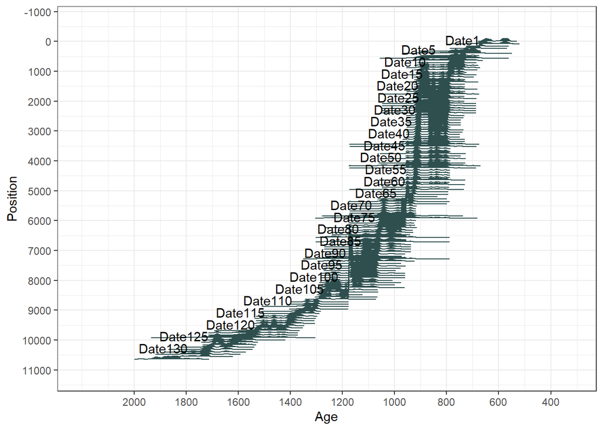

```r
alldata<-read.csv("../ALL_NMC_dates.csv")
#dates<-alldata[is.na(alldata$type)==F,]
#
plot(BchronCalibrate(ages=c(sort(alldata$uncal_age,decreasing=F)[20:153]),
                       ageSds=c(alldata$uncal_err[20:153]),
                       positions=seq(0,10640,80),
                       calCurves=rep('intcal20',nrow(alldata[20:153,]))),withPositions=T)
```

- A paleoclimatic reconstruction of the West Tavaputs Plateau

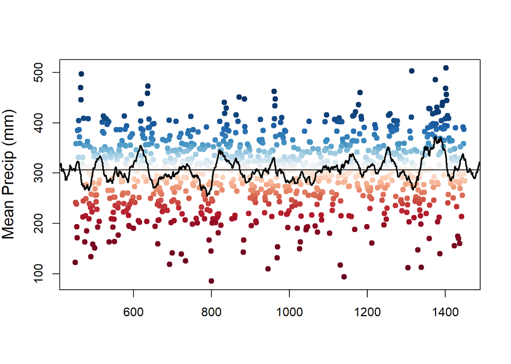

```r
ts.df<-read.csv("../timedata.csv")
ts.df<-ts.df[1:1584,]
#ts.df[is.na(ts.df)] <- 0
mean<-ts.df
mean1<-mean[500:1500,]
library(RColorBrewer)
ma <- function(arr, n=100){
  res = arr
  for(i in n:length(arr)){
    res[i] = mean(arr[(i-n):i])
  }
  res
}

RB<-brewer.pal(n = 11, name = 'RdBu')
pal = colorRampPalette(RB)
mean1$order = findInterval(mean1$Reg_mean, sort(mean1$Reg_mean))

plot(Reg_mean~yearBP,data=mean1, type="p", pch=19, col=pal(nrow(mean1))[mean1$order], lwd=1, ylab="Mean Precip (mm)", xlab="",cex.lab=1.3)

ma7yr<-ma(mean$Reg_mean, n=30) #7 year running average following Benson et al. 2013

lines(ma7yr~mean$yearBP, col="black", lwd=2)
abline(h=mean(mean1$Reg_mean))
```

```r
#comparison with the Knight et al 2008 data constructed using Harmon Canyon tree rings. Sample only extends back to 1200AD.
plot(ts.df$Reg_mean~ts.df$K_TR,ylab="PaleoCar Precipiptation Predictions (mm)",xlab="Knight et al 2008 Tree Ring Standardized Growth Index")
knight<-lm(Reg_mean~K_TR,data=ts.df)
summary(knight)
```

```
##
## Call:
## lm(formula = Reg_mean ~ K_TR, data = ts.df)
##
## Residuals:
##     Min      1Q  Median      3Q     Max
## -128.56  -28.57   -1.65   31.80  136.69
##
## Coefficients:
##             Estimate Std. Error t value Pr(>|t|)
## (Intercept)  303.451      2.434  124.68   <2e-16 ***
## K_TR          50.075      2.365   21.17   <2e-16 ***
## ---
## Signif. codes:  0 '***' 0.001 '**' 0.01 '*' 0.05 '.' 0.1 ' ' 1
##
## Residual standard error: 47.75 on 383 degrees of freedom
##   (1199 observations deleted due to missingness)
## Multiple R-squared:  0.5392, Adjusted R-squared:  0.538
## F-statistic: 448.2 on 1 and 383 DF,  p-value: < 2.2e-16
```

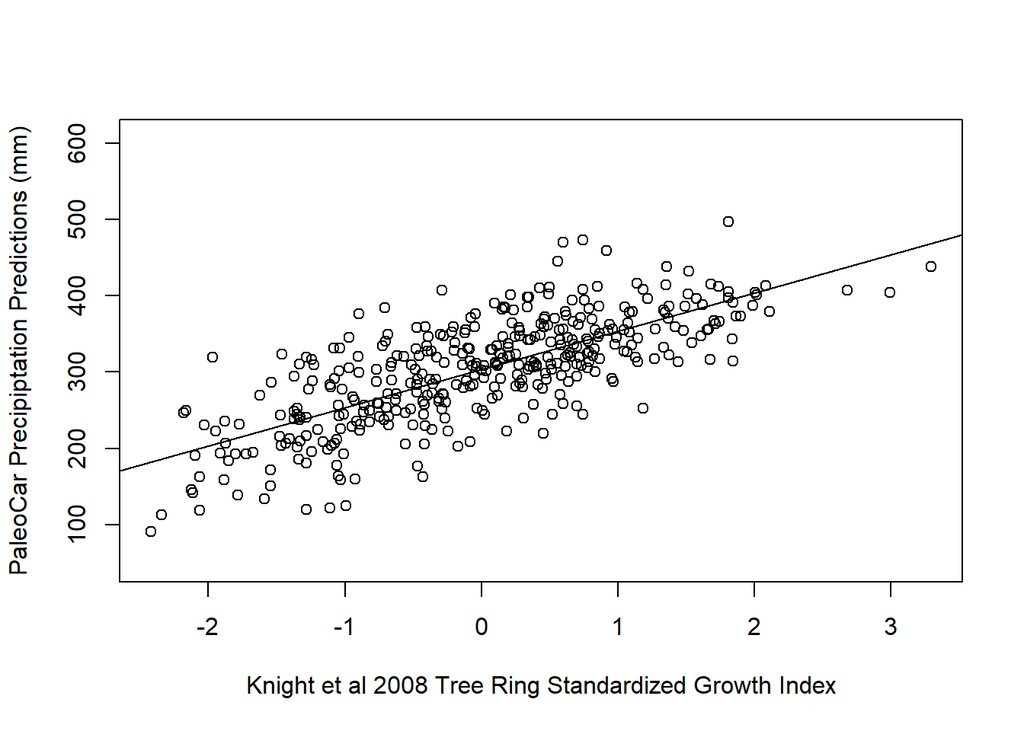

```r
abline(knight)
```

```r
cor(ts.df$Reg_mean,ts.df$K_TR,method="pearson",use="pairwise.complete.obs")
```

```
## [1] 0.7343036
```

```r
#High Positive Correlation
#plot(K_TR~yearBP,data=ts.df[1200:nrow(ts.df),], type="p", pch=19, col=pal(nrow(mean1))[mean1$order], lwd=1, ylab="Mean Precip (mm)", xlab="",cex.lab=1.3)
#lines(ma(ts.df$K_TR[1200:nrow(ts.df)],n=30)~ts.df$yearBP[1200:nrow(ts.df)])
```

Note: The averaging window size in years for the trend line is specified as `n` in the `ma` function

- Ramankutty GDD and Probability of cultivation data

This is the model that we will use later for probability of cultivation as a proxy of habitat suitability.

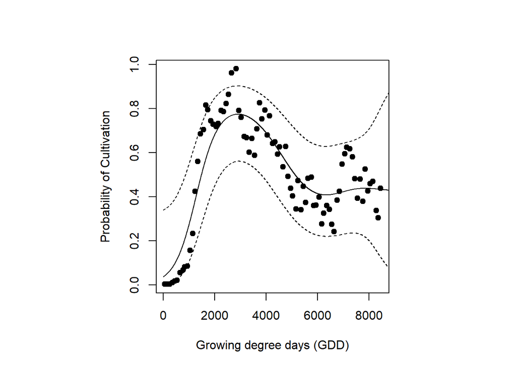

```r
raman<-read.csv("../ramankutty_probscultivation.csv")
raman.mod<-gam(Probs_Cul~s(gdd,k=11),data=raman,family="binomial")
newdata<-predict(raman.mod,
                 newdata=data.frame(gdd=seq(0,9000,1)
                  )
                  ,
                  se.fit=T)
par(pty="s")
plot(raman,pch=19, ylab="Probability of Cultivation",xlab="Growing degree days (GDD)")
 ilink <- family(raman.mod)$linkinv
 lines(seq(0,9000,1),ilink(newdata$fit))
 lines(seq(0,9000,1),ilink(newdata$fit+(2*newdata$se.fit)),lty=2)
 lines(seq(0,9000,1),ilink(newdata$fit-(2*newdata$se.fit)),lty=2)
```

- MI, NPP, and GDD

```r
allsp<-SpatialPointsDataFrame(coords=cbind(alldata$me.x,alldata$mn.x),proj4string=CRS("+init=epsg:26912"),data=alldata)
allsp<-spTransform(allsp,CRSobj=CRS("+init=epsg:4326"))
#just the state data for cropping
library(rgdal)
setwd("D:/Desktop/UTAH_Paleo")
states <- readOGR("./NATIONAL_ATLAS/statesp010g", layer='statesp010g')
```

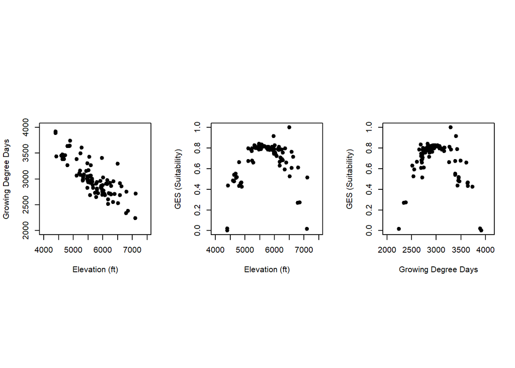

```r
states <- states[states$NAME %in% c("Utah"),]
#then we load our rasters
setwd("D:/Desktop/Grants/CPAA_GSENM/GSENM/Data/GIS/Rasters/Raw")
mi<-raster("./Rasters/MoistureIndex1.tif")
#mi<-projectRaster(from=mi, crs=CRS("+init=epsg:26912"), method="bilinear")

#npp
npp<-raster("./Rasters/MOD17A3_Science_NPP_mean_00_15.tif")
npp<-crop(npp,states)
#npp<-projectRaster(from=npp, crs=CRS("+init=epsg:26912"), method="bilinear")

#gdd
gdd<-raster("../DEM_ext/epsg_4326/complete/GDD_corngrowing_dds_2005/YNWL_50n.asc")

#extract the values to the df
alldata$mi<-extract(mi,allsp)
alldata$npp<-extract(npp,allsp)
alldata$gdd<-extract(gdd,allsp)

alldata$f1<-(1/(1+exp(0.00052*(1334-alldata$gdd))))*alldata$mi
npp[npp==65535]<-NA

alldata$gde<-scale(alldata$gdd)*scale(alldata$elev)
alldata$probscul<-predict(raman.mod,newdata=data.frame(gdd=alldata$gdd))
ilink <- family(raman.mod)$linkinv
alldata$probscul<-ilink(alldata$probscul)

#explaining GDE
ranger<-range01(alldata$gde)
par(mfrow=c(1,3))
par(pty="s")
plot(alldata$gdd~alldata$elevation,pch=19,xlim=c(4000,7500),ylim=c(2000,4000),xlab="Elevation (ft)",ylab="Growing Degree Days")
plot(ranger~alldata$elevation,pch=19,xlim=c(4000,7500),xlab="Elevation (ft)",ylab="GES (Suitability)")
plot(ranger~alldata$gdd,pch=19,xlim=c(2000,4100),ylab="GES (Suitability)", xlab="Growing Degree Days")
```

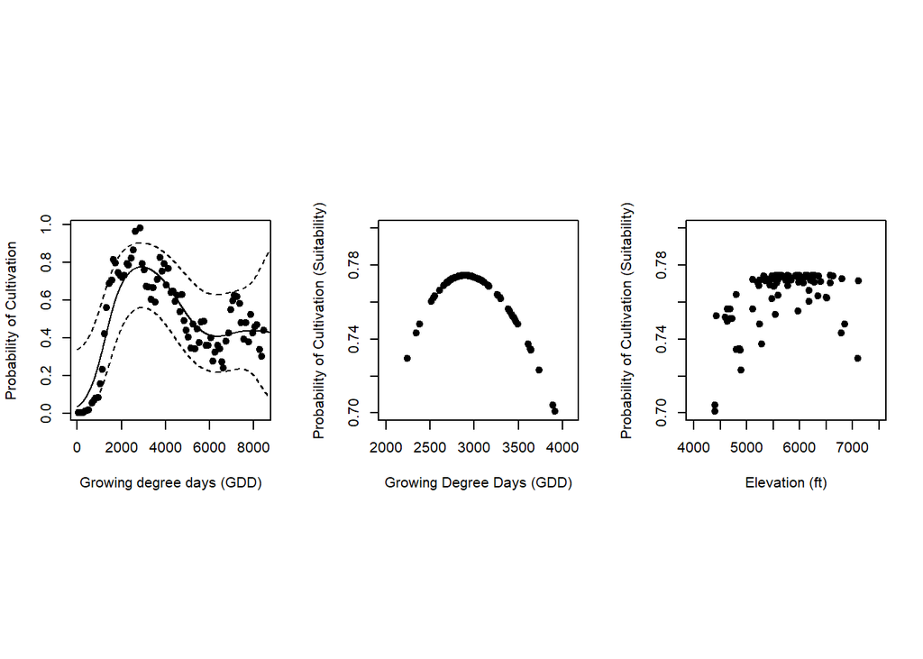

```r
#explaining Probs Cul
par(mfrow=c(1,3))
plot(raman,pch=19, ylab="Probability of Cultivation",xlab="Growing degree days (GDD)")
 ilink <- family(raman.mod)$linkinv
 lines(seq(0,9000,1),ilink(newdata$fit))
 lines(seq(0,9000,1),ilink(newdata$fit+(2*newdata$se.fit)),lty=2)
 lines(seq(0,9000,1),ilink(newdata$fit-(2*newdata$se.fit)),lty=2)

 plot(alldata$probscul~alldata$gdd,pch=19,xlim=c(2000,4100),ylab="Probability of Cultivation (Suitability)", xlab="Growing Degree Days (GDD)",ylim=c(0.7,0.8))
  plot(alldata$probscul~alldata$elevation,pch=19,ylab="Probability of Cultivation (Suitability)", xlab="Elevation (ft)",ylim=c(0.7,0.8),xlim=c(4000,7500))
```

```r
#projecting the raman.mod across GDD for the state to visualize the suitability raster.
#names(gdd)<-"gdd"
#pc<-raster::predict(object=gdd,model=raman.mod,type="response")
#not much to do with this, but what if we do mi*gdd
#mir<-resample(mi,gdd,"bilinear")
#plot(mir*pc)
```

- SPD using bins to account for dates at multiple sites and a 100 year averaging window for smoothing.

```r
par(pty="s")
##corn dates
corn<-alldata[alldata$samp_mat=="Zea Mays",]
cd<-calibrate(x=corn$uncal_age,
              errors=corn$uncal_err,
              calCurves=rep("intcal20",nrow(corn)))
```

```
## [1] "Calibrating radiocarbon ages..."
##
## [1] "Done."
```

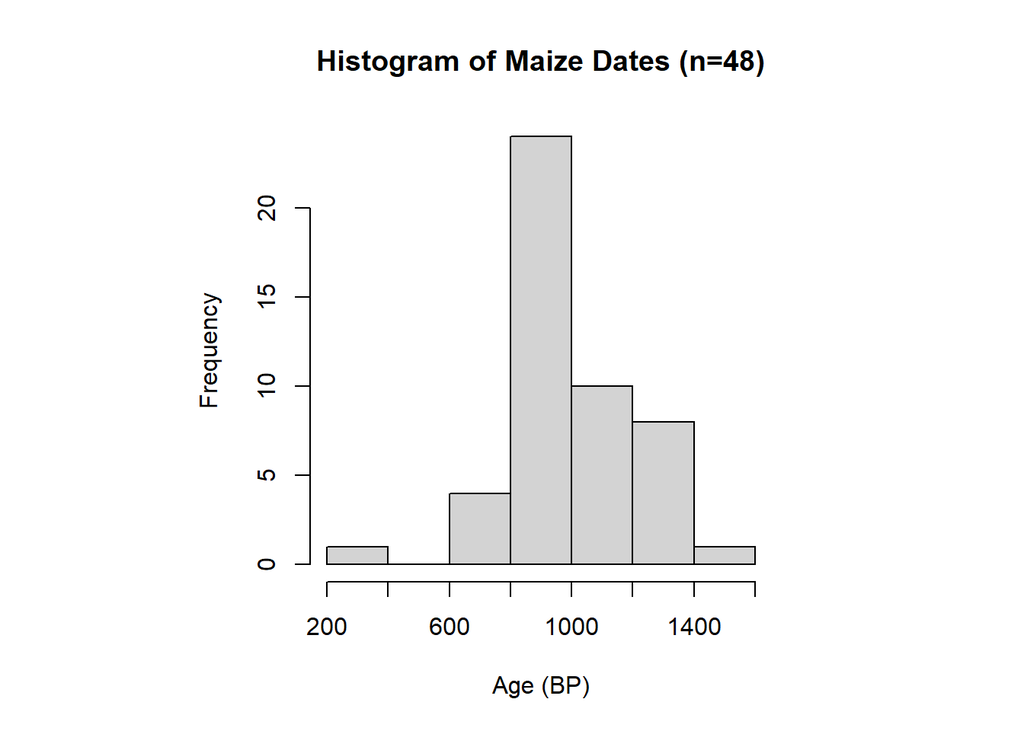

```r
hist(summary(cd)$MedianBP,main="Histogram of Maize Dates (n=48)", xlab= "Age (BP)")
```

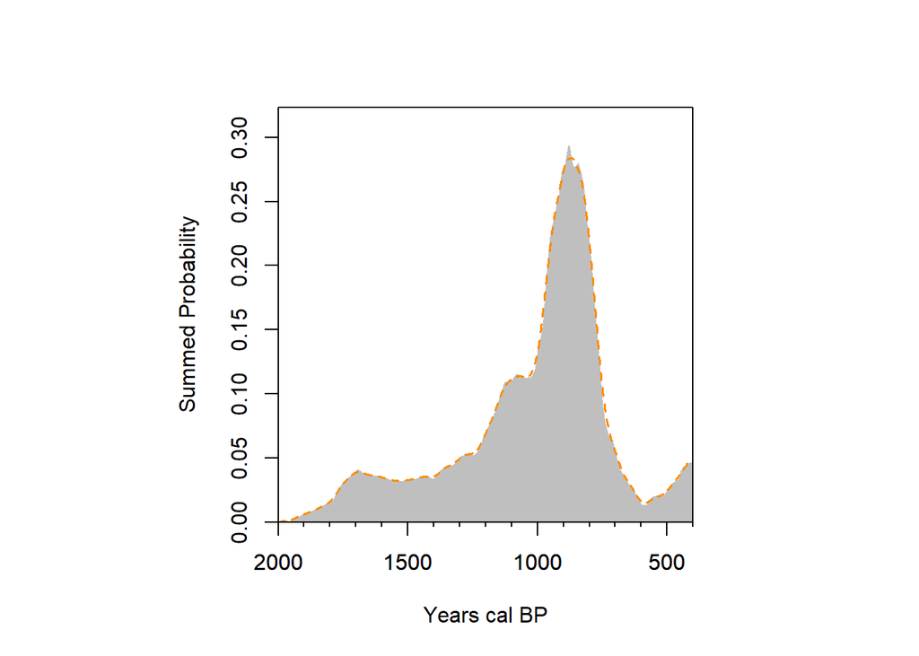

```r
caldates<-calibrate(x=alldata$uncal_age,errors=alldata$uncal_err,calCurves='intcal20',verbose=F)

#with bins
DK.bins = binPrep(sites=alldata$site,ages=alldata$uncal_age,h=100)
calspd=spd(caldates,bins=DK.bins,timeRange = c(2000,400),runm=100,verbose=F)
plot(calspd)
plot(calspd,runm=50,type="simple",col="darkorange",lwd=1.5,lty=2,add=T)
```

## Analysis

```r
df<-data.frame(yearBP=calspd$grid$calBP,
               spd=calspd$grid$PrDens,
               meanGDE=NA,
               meanprecip=NA,
               avgmeanprecip=NA)

mean$avgprecip<-ma7yr
df<-merge(df,mean[,c(2,6,15)],by="yearBP",all.x=T)

meangde<-data.frame(yearBP=calspd$grid$calBP)
for (i in 1:nrow(alldata)){
  #meangde[,1+i]<-paste("gde",i,sep="")
  dates<-calibrate(x=alldata$uncal_age[i],errors=alldata$uncal_err[i],calCurves='intcal20',verbose=F)

  x<-data.frame(yearBP=dates$grids$'1'$calBP,gde=alldata$gde[i])
                #*dates$grids$"1"$PrDens)
  meangde<-merge(meangde,x,by="yearBP",all=T)

  #above i multiply the probability of the density function by gde as a weight of how likely that year is.
}


for (i in 1:nrow(meangde)){
 test<-meangde[i,]
 test<-t(test)
 year<-test[1,]
 test<-test[-1,]
 meany<-mean(na.omit(test))
 df[df$yearBP==year,3]<-meany # 3 because crit is the 3rd column in the df
}

df<-df[,-c(4,5)]

###########################################################################################
####################

###############################################################################
###############################################################################
#####elev
#######################################################################
df$meanelev<-NA
df$medelev<-NA
#selecting out only the stor sites
#stors<-alldata[is.na(alldata$type)==F,]

#now to make a table to make counts
elev<-data.frame(yearBP=calspd$grid$calBP)
for (i in 1:nrow(alldata)){
  #meangde[,1+i]<-paste("gde",i,sep="")
  dates<-calibrate(x=alldata$uncal_age[i],errors=alldata$uncal_err[i],calCurves='intcal20',verbose=F)

  x<-data.frame(yearBP=dates$grids$'1'$calBP,gde=alldata$elevation[i])
                #*dates$grids$"1"$PrDens) #1 times the prob density in an attempt to weight that number of storage features
  elev<-merge(elev,x,by="yearBP",all=T)

}


########################################################################
########GDD########
###########################################
###########################################
df$meangdd<-NA
df$medgdd<-NA
#selecting out only the stor sites
#stors<-alldata[is.na(alldata$type)==F,]

#now to make a table to make counts
gdd<-data.frame(yearBP=calspd$grid$calBP)
for (i in 1:nrow(alldata)){
  #meangde[,1+i]<-paste("gde",i,sep="")
  dates<-calibrate(x=alldata$uncal_age[i],errors=alldata$uncal_err[i],calCurves='intcal20',verbose=F)

  x<-data.frame(yearBP=dates$grids$'1'$calBP,gde=alldata$gdd[i])
                #*dates$grids$"1"$PrDens) #1 times the prob density in an attempt to weight that number of storage features
  gdd<-merge(gdd,x,by="yearBP",all=T)

}

#putting this into the main df, df
for (i in 401:2001){
  test<-gdd[i,]
  test<-t(test)
  test<-test[-1,]
  df$meangdd[i-400]<-mean(na.omit(test))
  df$medgdd[i-400]<-median(na.omit(test))

}

##########################
########Probs Cul########
###########################################
###########################################
df$meanprobscul<-NA

#selecting out only the stor sites
#stors<-alldata[is.na(alldata$type)==F,]

#now to make a table to make counts
probscul<-data.frame(yearBP=calspd$grid$calBP)
for (i in 1:nrow(alldata)){
  #meangde[,1+i]<-paste("gde",i,sep="")
  dates<-calibrate(x=alldata$uncal_age[i],errors=alldata$uncal_err[i],calCurves='intcal20',verbose=F)

  x<-data.frame(yearBP=dates$grids$'1'$calBP,gde=alldata$probscul[i]) #1 times the prob density in an attempt to weight that number of storage features
  probscul<-merge(probscul,x,by="yearBP",all=T)

}



for (i in 1:nrow(probscul)){
 test<-probscul[i,]
 test<-t(test)
 year<-test[1,]
 test<-test[-1,]
 meany<-mean(na.omit(test))
 df[df$yearBP==year,10]<-meany # 3 because crit is the 3rd column in the df
}
```

*Note: Dataframe is cropped to only include data from 2kya-600ya.

Questions: - Am I plotting these correctly? Some of the y-axes look weird. - I’m using a gaussian family and I’m not sure if that is the most appropriate. - Which models need the AR model and which don’t? - Which models should I drop (if any)?

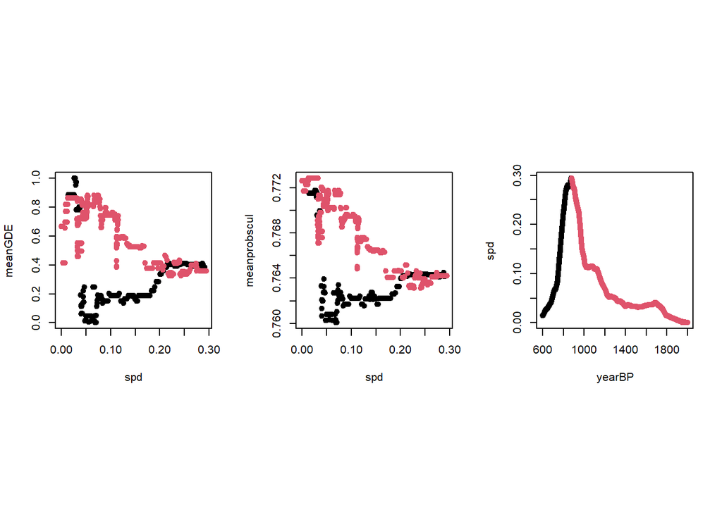

```r
df2<-df
df<-df[c(201:1601),] #2000-600BP
par(pty="s")
#par(mfrow=c(1,3))



##################
###seems like something weird is going on which might be attributable to periods of settlement and abandonment being different processes

df$aors<-NA
df$aors[279:nrow(df)]<-1
df$aors[1:278]<-0
df$meanGDE<-range01(df$meanGDE)

par(mfrow=c(1,3))
plot(meanGDE~spd,df,col=df$aors+1,pch=19)
plot(meanprobscul~spd,df,col=df$aors+1,pch=19)
plot(spd~yearBP,df,col=df$aors+1,pch=19)
```

```r
###########Mean GDE
#gamm
mod1<-gamm(meanGDE~s(avgprecip,k=2)+s(spd)+aors,data=df,correlation=corAR1())
summary(mod1$gam)
```

```
##
## Family: gaussian
## Link function: identity
##
## Formula:
## meanGDE ~ s(avgprecip, k = 2) + s(spd) + aors
##
## Parametric coefficients:
##             Estimate Std. Error t value Pr(>|t|)
## (Intercept) 0.614543   0.068681   8.948   <2e-16 ***
## aors        0.003588   0.029091   0.123    0.902
## ---
## Signif. codes:  0 '***' 0.001 '**' 0.01 '*' 0.05 '.' 0.1 ' ' 1
##
## Approximate significance of smooth terms:
##                edf Ref.df     F p-value
## s(avgprecip) 1.298  1.298 0.458   0.415
## s(spd)       1.000  1.000 1.869   0.172
##
## R-sq.(adj) =  0.198
##   Scale est. = 0.037393  n = 1350
```

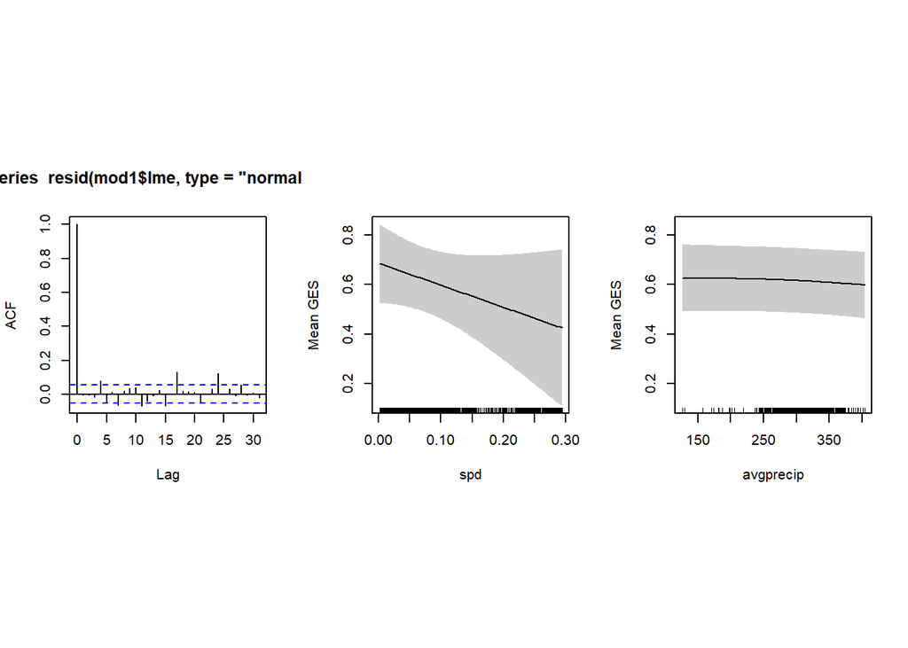

```r
acf(resid(mod1$lme,type="normalized"))

plot(mod1$gam,shift=mod1$gam$coefficients[1],shade=T,select=2,seWithMean=TRUE,ylab="Mean GES");box()
plot(mod1$gam,shift=mod1$gam$coefficients[1],shade=T,select=1,seWithMean=TRUE,ylab="Mean GES");box()
```

```r
#diagnostics
#deviance explained
mod0<-gam(meanGDE~1,data=df)
 DN <- sum(residuals(mod0, type = "pearson")^2) # Deviance from NULL GAMM
 DR <- sum(residuals(mod1$gam, type = "pearson")^2) # Deviance from our GAMM
 DE <- (DN-DR)*100/DN; DE # Deviance Explained from our GAMM model
```

```
## [1] 19.96562
```

```r
#residuals
summary(residuals(mod1$lme,type="normalized"))
```

```
##       Min.    1st Qu.     Median       Mean    3rd Qu.       Max.
## -20.482489  -0.064490   0.010016  -0.009936   0.064066   8.308650
```

```r
#dispersion
resid.ssq <- sum(residuals(mod1$lme,type="pearson")^2)        ## sum of squares of Pearson resids
resid.df <- summary(mod1$gam)$n - length(coef(mod1$lme))  ## estimated resid df (N-p), or gam.fish$gam$df.residual
resid.ssq/resid.df
```

```
## [1] 1.033072
```

```r
#underfitting
k.check(mod1$gam)
```

```
##              k'      edf   k-index p-value
## s(avgprecip)  2 1.297717 0.8884852       0
## s(spd)        9 1.000000 0.8469309       0
```

```r
###################PC
##gammmm

mod1<-gamm(meanprobscul~s(spd)+s(avgprecip)+aors,data=df,correlation=corAR1())
summary(mod1$gam)
```

```
##
## Family: gaussian
## Link function: identity
##
## Formula:
## meanprobscul ~ s(spd) + s(avgprecip) + aors
##
## Parametric coefficients:
##              Estimate Std. Error t value Pr(>|t|)
## (Intercept) 7.687e-01  1.043e-03  737.16   <2e-16 ***
## aors        4.292e-05  3.304e-04    0.13    0.897
## ---
## Signif. codes:  0 '***' 0.001 '**' 0.01 '*' 0.05 '.' 0.1 ' ' 1
##
## Approximate significance of smooth terms:
##              edf Ref.df     F p-value
## s(spd)         1      1 3.955  0.0469 *
## s(avgprecip)   1      1 0.065  0.7983
## ---
## Signif. codes:  0 '***' 0.001 '**' 0.01 '*' 0.05 '.' 0.1 ' ' 1
##
## R-sq.(adj) =  0.375
##   Scale est. = 6.7028e-06  n = 1350
```

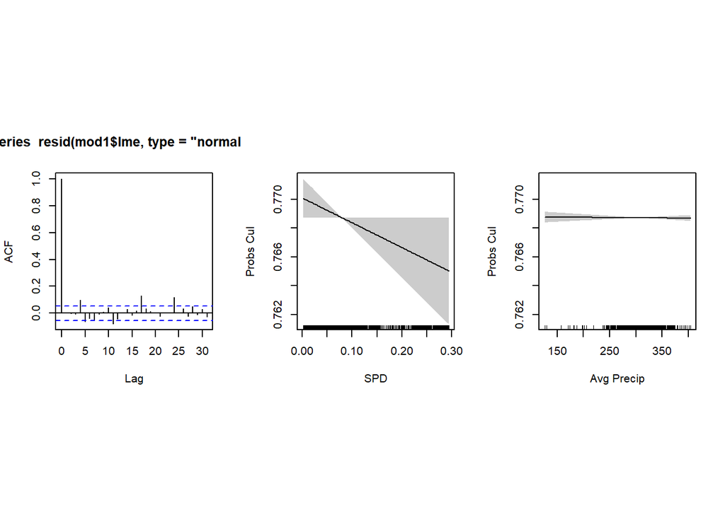

```r
acf(resid(mod1$lme,type="normalized"))


plot(mod1$gam,select=1,shade=T,ylab="Probs Cul",xlab="SPD",shift= coef(mod1$gam)[1])
plot(mod1$gam,select=2,shade=T,ylab="Probs Cul",xlab="Avg Precip",shift= coef(mod1$gam)[1])
```

```r
#diagnostics
#deviance explained
mod0<-gam(meanprobscul~1,data=df)
 DN <- sum(residuals(mod0, type = "pearson")^2) # Deviance from NULL GAMM
 DR <- sum(residuals(mod1$gam, type = "pearson")^2) # Deviance from our GAMM
 DE <- (DN-DR)*100/DN; DE # Deviance Explained from our GAMM model
```

```
## [1] 39.79699
```

```r
#residuals
summary(residuals(mod1$lme,type="normalized"))
```

```
##       Min.    1st Qu.     Median       Mean    3rd Qu.       Max.
## -19.481640  -0.046195   0.002812  -0.006877   0.054671   9.176087
```

```r
#dispersion
resid.ssq <- sum(residuals(mod1$lme,type="pearson")^2)        ## sum of squares of Pearson resids
resid.df <- summary(mod1$gam)$n - length(coef(mod1$lme))  ## estimated resid df (N-p), or gam.fish$gam$df.residual
resid.ssq/resid.df
```

```
## [1] 1.045892
```

```r
#underfitting
k.check(mod1$gam)
```

```
##              k'      edf   k-index p-value
## s(spd)        9 1.000009 0.7832539       0
## s(avgprecip)  9 1.000000 0.8230580       0
```

## Results

The number of storage features is attributable to spd/population, with more storage features being built when there are more people on the landscape.

There is likely other variables at play not included in this model that could explain residual deviation, such as prehistorical events, climatic events not captured in our precipitation measure, technological developments, and regional developments in human population and subsistence transitions.

Residual deviation might also be explained by uncertainties within the radiocarbon distributions. Many of the radiocarbon distributions are bimodal as a result of the calibration curve. This may explain some of the patterning in our model residuals.

Other variables that we could include: - Proportion of diet attributed to maize determined using stable isotopes from human remains -

There does seem to be some effect of precipitation on populations, which makes sense, but for the West Tavaputs, precipitation does not seem to be as important. This is likely a result of the permanent water sources near all the sites used in this analysis. Rain fed agriculture may not have been as important as a result and people were likely more reliant on the avaialbility of water within the permanent creek systems for irrigating fields. The West Tavaputs environment makes for some interesting challenges in regards to water control. Rainfall during the growing season is unpredictable and often torrential. The unpredictability and intensity of these rainstorms makes farming in high drainage areas, like canyon bottoms, potentially dangerous and destructive. As such, irrigated agriculture within the canyons on the West Tavaputs was likely the best method for farming.

# Storage Analyses

Now to test ideas about storage. I think I should use just my own Nine Mile data so this should be the masterdata_w_spatial.csv. We will need to create the dataframe again with mean #stor, VS, and elevation above FP.

These are just the Nine Mile Canyon data I collected. The reason we are using these data instead of the full dataset is that that these data have high accuracy UTM data, which is necessary for determining viewshed and elevation above the floodplain. Additionally, the raster created for determining elevation above the flood plain only currently exists for Nine Mile Canyon.

We will still be using the SPD data for the entire Tavaputs.

First, lets load just this data.

```r
setwd("D:/Desktop/Dissertation")
masterdata<-read.csv("./masterdata_w_spatial.csv")
#making sure UTMs are all in one place (corrected and correct)
##easting
for (i in 1:nrow(masterdata)){
  row<-i
  if (is.na(masterdata[i,9])==FALSE){
    masterdata[i,9]<-masterdata[i,9]}
  else {
    masterdata[i,9]<-masterdata[i,12]
  }
}

##northing
for (i in 1:nrow(masterdata)){
  row<-i
  if (is.na(masterdata[i,10])==FALSE){
    masterdata[i,10]<-masterdata[i,10]}
  else {
    masterdata[i,10]<-masterdata[i,13]
  }
}

#removing all those without UTM data
masterdata<-masterdata[complete.cases(masterdata$mE_corrected), ]
#just the columns we are interested in
data<-masterdata[!is.na(masterdata$uncal_age),]
#dumping the modern date
data<-data[-22,]
dates<-data[,c(2,3,4,7,8,13,14,34,36,37,89,90,91,92,93,94,95,96,97)]
stors<-na.omit(dates)
head(stors)
```

```
##          id site.x f.x field_state C14_state     me.x    mn.x samp_material
## 2 cb0048-2a cb0048   2     visited         Y 571139.5 4401676         adobe
## 3 cb0742-1a cb0742   1     visited         Y 570128.1 4404383         adobe
## 4 cb0791-1a cb0791   1     visited         Y 570306.2 4404674         adobe
## 5 cb0861-1a cb0861   1     visited         Y 572841.2 4404332         adobe
## 6 cb0876-1a cb0876   1     visited         Y 574549.9 4400296         adobe
## 7 cb0965-1a cb0965   1     visited         Y 573919.4 4403156         adobe
##   uncal_age uncal_err elevtnr   aspectr rghnssr  TRIr    sloper   elvbvFP
## 2       720        20    1714 108.43495       1 0.250  4.520228  2.057555
## 3      1560        20    1698  38.15723      13 3.250 41.676265 31.455999
## 4      1080        20    1716 235.30485       7 1.625 21.568129 45.093399
## 5       960        20    1648 186.34019       6 1.750 24.359556 11.843300
## 6      1260        20    1806 270.00000       4 1.250 19.290046 51.594700
## 7      1000        20    1725 154.72228      24 8.125 63.326860 76.525330
##         CDr VS_fp VS_tot
## 2 57.777783   402  19255
## 3  7.623015  4038  39034
## 4 11.583233  5330  56463
## 5 34.349691  2454  37152
## 6 84.653970     0  25479
## 7 48.340018  1022  18313
```

## Data Creation

Creating the dataframe we will use for analysis. Here, I am using:

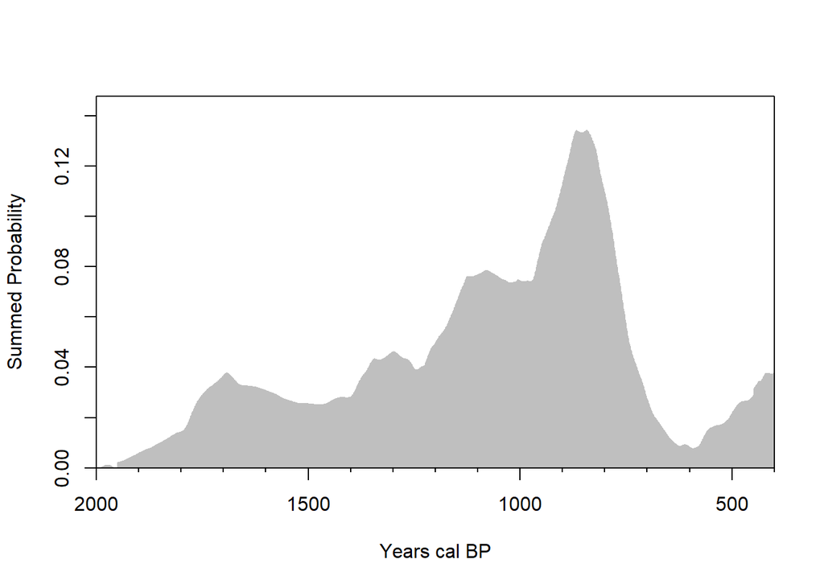

```r
###number of stors
notstors<-alldata[is.na(alldata$type)==T,]
caldates1<-calibrate(x=notstors$uncal_age,errors=notstors$uncal_err,calCurves='intcal20',verbose=F)
DK.bins1 = binPrep(sites=notstors$site,ages=notstors$uncal_age,h=100)
calspd1=spd(caldates1,bins=DK.bins1,timeRange = c(2000,400),runm=100,verbose=F)

plot(calspd1)
```

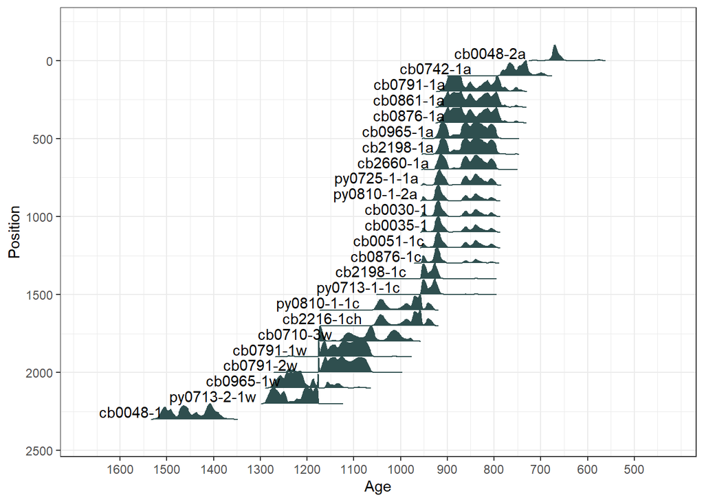

```r
#df with yearBP,spd.y (stors excluded),mean precip, mean numstor, mean vs, mean elevation above fp
df1<-df
df<-data.frame(yearBP=calspd1$grid$calBP,
               spd=calspd1$grid$PrDens,
               meanprobscul=NA
               )

df<-merge(df,mean[,c(2,6,15)],by="yearBP",all.x=T)
df$meanprobscul<-df2$meanprobscul

#################################
#counting the stors in use in NMC
df$numstor<-NA
#selecting out only the stor sites

stors<-stors

#now to make a table to make counts
stornum<-data.frame(yearBP=calspd$grid$calBP)
for (i in 1:nrow(stors)){

  dates<-calibrate(x=stors$uncal_age[i],errors=stors$uncal_err[i],calCurves='intcal20',verbose=F)

  x<-data.frame(yearBP=dates$grids$'1'$calBP,stornum=1)
                #*dates$grids$"1"$PrDens) #1 times the prob density in an attempt to weight that number of storage features
  stornum<-merge(stornum,x,by="yearBP",all=T)

}



for (i in 1:nrow(stornum)){
 test<-stornum[i,]
 test<-t(test)
 year<-test[1,]
 test<-test[-1,]
 meany<-sum(na.omit(test))
 df[df$yearBP==year,6]<-meany # 3 because crit is the 3rd column in the df
}


###okay, now we have num stor
#now for VS
VS<-data.frame(yearBP=calspd$grid$calBP)
for (i in 1:nrow(stors)){

  dates<-calibrate(x=stors$uncal_age[i],errors=stors$uncal_err[i],calCurves='intcal20',verbose=F)

  x<-data.frame(yearBP=dates$grids$'1'$calBP,gde=stors$VS_fp[i])
                #*dates$grids$"1"$PrDens) #1 times the prob density in an attempt to weight that number of storage features
  VS<-merge(VS,x,by="yearBP",all=T)

}

df$VS<-NA
for (i in 1:nrow(VS)){
 test<-VS[i,]
 test<-t(test)
 year<-test[1,]
 test<-test[-1,]
 meany<-mean(na.omit(test))
 df[df$yearBP==year,7]<-meany # 3 because crit is the 3rd column in the df
}


#now for elevation above the floodplain
elevfp<-data.frame(yearBP=calspd$grid$calBP)
for (i in 1:nrow(stors)){

  dates<-calibrate(x=stors$uncal_age[i],errors=stors$uncal_err[i],calCurves='intcal20',verbose=F)

  x<-data.frame(yearBP=dates$grids$'1'$calBP,gde=stors$elvbvFP[i])
                #*dates$grids$"1"$PrDens) #1 times the prob density in an attempt to weight that number of storage features
  elevfp<-merge(elevfp,x,by="yearBP",all=T)

}

df$elevfp<-NA
for (i in 1:nrow(elevfp)){
 test<-elevfp[i,]
 test<-t(test)
 year<-test[1,]
 test<-test[-1,]
 meany<-mean(na.omit(test))
 df[df$yearBP==year,8]<-meany # 3 because crit is the 3rd column in the df
}

#df$meanprobscul<-range01(df$meanprobscul)

plot(BchronCalibrate(ages=c(sort(stors$uncal_age,decreasing=F)),
                       ageSds=c(stors$uncal_err),
                       positions=seq(0,2300,100),
                       calCurves=rep('intcal20',nrow(stors)),ids=stors$id),withPositions=T)
```

## Analyses 2

Next we will analyze these data. We use an autoregressive generalized additive mixed model (GAMM).

First, we look at the number of storage features in use relative to precipitation, population and mean suitability of occupied habitats.

Next we look at the mean viewshed of occupied of in use storage features relative to precipitation, population and mean suitability of occupied habitats.

Last we look at mean elevation above the floodplain of in use storage features.

```r
par(pty="s")
par(mfrow=c(1,3))
###############################
#Number of stors
#mod1<-gam(numstor~s(avgprecip)+s(spd,k=2)+s(meanGDE),data=df)
#summary(mod1)
#hist(residuals(mod1))
#acf(resid(mod1),lag.max=1000)
#plot(mod1,select=1,shade=T,residuals=T,ylab="Num Stor",xlab="Average Precip",shift= ilink(coef(mod1)[1]))
#plot(mod1,select=2,shade=T,residuals=T,ylab="Num Stor",xlab="SPD",shift= ilink(coef(mod1)[1]))
#plot(mod1,select=3,shade=T,residuals=T,ylab="Num Stor",xlab="GDE",shift= ilink(coef(mod1)[1]))
df$aors<-NA
df$aors[451:nrow(df)]<-1
df$aors[1:451]<-0
df<-df[201:nrow(df),]

#gamm
mod1<-gamm(numstor~s(avgprecip)+s(spd)+aors,data=df,correlation=corAR1())
summary(mod1$gam)
```

```
##
## Family: gaussian
## Link function: identity
##
## Formula:
## numstor ~ s(avgprecip) + s(spd) + aors
##
## Parametric coefficients:
##             Estimate Std. Error t value Pr(>|t|)
## (Intercept)  3.17953    0.33391   9.522   <2e-16 ***
## aors        -0.06345    0.28857  -0.220    0.826
## ---
## Signif. codes:  0 '***' 0.001 '**' 0.01 '*' 0.05 '.' 0.1 ' ' 1
##
## Approximate significance of smooth terms:
##                edf Ref.df      F p-value
## s(avgprecip) 1.000  1.000  0.024   0.876
## s(spd)       6.685  6.685 49.581  <2e-16 ***
## ---
## Signif. codes:  0 '***' 0.001 '**' 0.01 '*' 0.05 '.' 0.1 ' ' 1
##
## R-sq.(adj) =  0.931
##   Scale est. = 1.4508    n = 1350
```

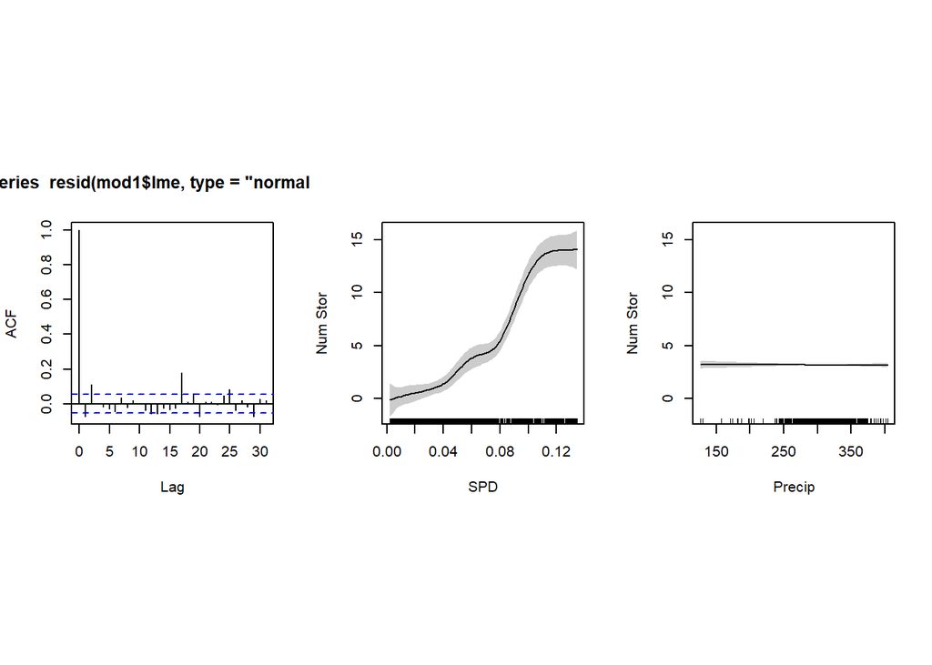

```r
#hist(resid(mod1$gam),main="NumStor~SPD+AvgPrecip")
acf(resid(mod1$lme,type="normalized"))

#plot(mod1$gam,select=1,shade=T,residuals=T,ylab="Num Stor",xlab="Average Precip",shift= ilink(coef(mod1$gam)[1]))
#plot(mod1$gam,select=2,shade=T,residuals=T,ylab="Num Stor",xlab="SPD",shift= ilink(coef(mod1$gam)[1]))
plot(mod1$gam,select=2,shade=T,ylab="Num Stor",xlab="SPD",shift=coef(mod1$gam)[1]);box()

plot(mod1$gam,select=1,shade=T,ylab="Num Stor",xlab="Precip",shift=coef(mod1$gam)[1]);box()
```

```r
df$normstor<-df$numstor/(df$spd*100)
mod2<-gamm(normstor~s(avgprecip)+s(meanprobscul,k=2)+aors,correlation=corAR1(),data=df[c(TRUE, rep(FALSE, 9)),])#
summary(mod2$gam)
```

```
##
## Family: gaussian
## Link function: identity
##
## Formula:
## normstor ~ s(avgprecip) + s(meanprobscul, k = 2) + aors
##
## Parametric coefficients:
##             Estimate Std. Error t value Pr(>|t|)
## (Intercept)  0.41555    0.16242   2.559   0.0117 *
## aors        -0.01754    0.14663  -0.120   0.9050
## ---
## Signif. codes:  0 '***' 0.001 '**' 0.01 '*' 0.05 '.' 0.1 ' ' 1
##
## Approximate significance of smooth terms:
##                   edf Ref.df     F p-value
## s(avgprecip)    1.000  1.000 1.369 0.24414
## s(meanprobscul) 1.402  1.402 7.619 0.00933 **
## ---
## Signif. codes:  0 '***' 0.001 '**' 0.01 '*' 0.05 '.' 0.1 ' ' 1
##
## R-sq.(adj) =  0.281
##   Scale est. = 0.12045   n = 135
```

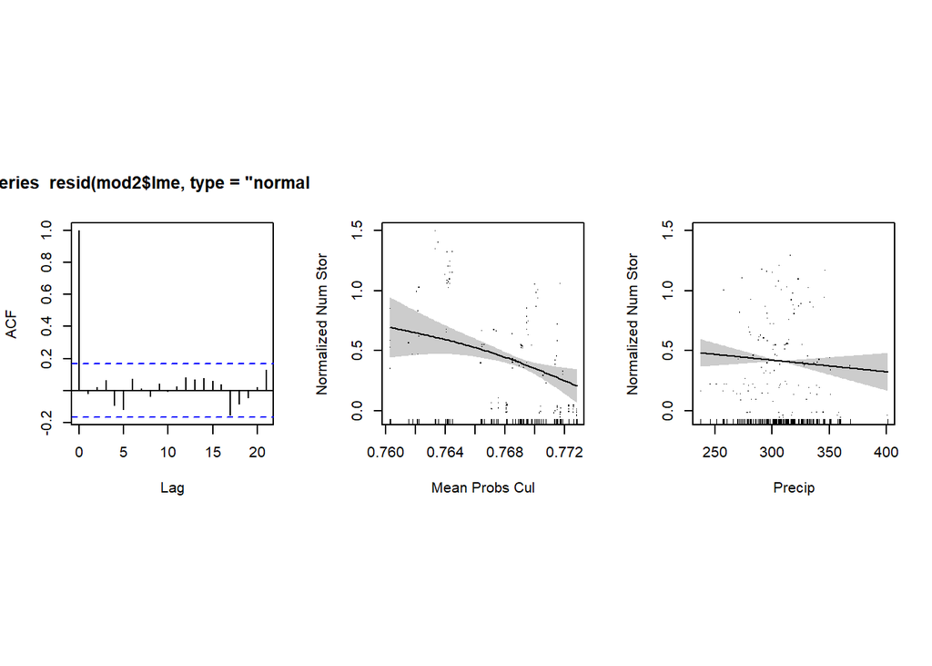

```r
acf(resid(mod2$lme,type="normalized"))
plot(mod2$gam,select=2,shade=T,ylab="Normalized Num Stor",xlab="Mean Probs Cul",shift=coef(mod2$gam)[1], residuals=T);box()

plot(mod2$gam,select=1,shade=T,ylab="Normalized Num Stor",xlab="Precip",shift=coef(mod2$gam)[1],residuals=T);box()
```

```r
###
#deviance explained
mod0<-gam(numstor~1,data=df)
 DN <- sum(residuals(mod0, type = "pearson")^2) # Deviance from NULL GAMM
 DR <- sum(residuals(mod1$gam, type = "pearson")^2) # Deviance from our GAMM
 DE <- (DN-DR)*100/DN; DE # Deviance Explained from our GAMM model
```

```
## [1] 93.26113
```

```r
#residuals

hist(residuals(mod1$lme,
              type="normalized"),
    main=NA,
    xlab="Residuals",
    col="grey")

#dispersion
resid.ssq <- sum(residuals(mod1$lme,type="pearson")^2)        ## sum of squares of Pearson resids
resid.df <- summary(mod1$gam)$n - length(coef(mod1$lme))  ## estimated resid df (N-p), or gam.fish$gam$df.residual
resid.ssq/resid.df
```

```
## [1] 0.8936238
```

```r
#underfitting
k.check(mod1$gam)
```

```
##              k'      edf   k-index p-value
## s(avgprecip)  9 1.000000 0.8657608       0
## s(spd)        9 6.684561 0.8378950       0
```

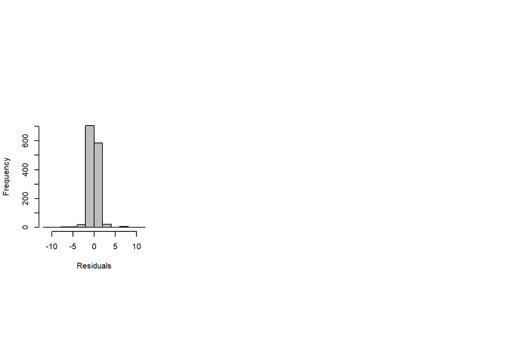

```r
########################################################################
#################
#Viewshed
#mod1<-gam(VS~s(avgprecip)+s(spd,k=2)+s(meanGDE),data=df)
#summary(mod1)
#hist(residuals(mod1))
#acf(resid(mod1),lag.max=1000)
par(pty="s")
par(mfrow=c(1,3))
```

```r
#gamm
mod1<-gamm(VS~s(avgprecip)+s(spd)+aors,data=df[c(TRUE, rep(FALSE, 9)),],correlation=corAR1())
#gamm(normstor~s(avgprecip)+s(meanprobscul,k=2)+aors,correlation=corAR1(),data=df[c(TRUE, rep(FALSE, 9)),])
summary(mod1$gam)
```

```
##
## Family: gaussian
## Link function: identity
##
## Formula:
## VS ~ s(avgprecip) + s(spd) + aors
##
## Parametric coefficients:
##             Estimate Std. Error t value Pr(>|t|)
## (Intercept)   2382.9      763.8   3.120  0.00253 **
## aors           138.2      567.7   0.243  0.80827
## ---
## Signif. codes:  0 '***' 0.001 '**' 0.01 '*' 0.05 '.' 0.1 ' ' 1
##
## Approximate significance of smooth terms:
##                edf Ref.df     F p-value
## s(avgprecip) 2.203  2.203 4.426  0.0163 *
## s(spd)       1.000  1.000 0.183  0.6697
## ---
## Signif. codes:  0 '***' 0.001 '**' 0.01 '*' 0.05 '.' 0.1 ' ' 1
##
## R-sq.(adj) =  0.0811
##   Scale est. = 1.9747e+06  n = 84
```

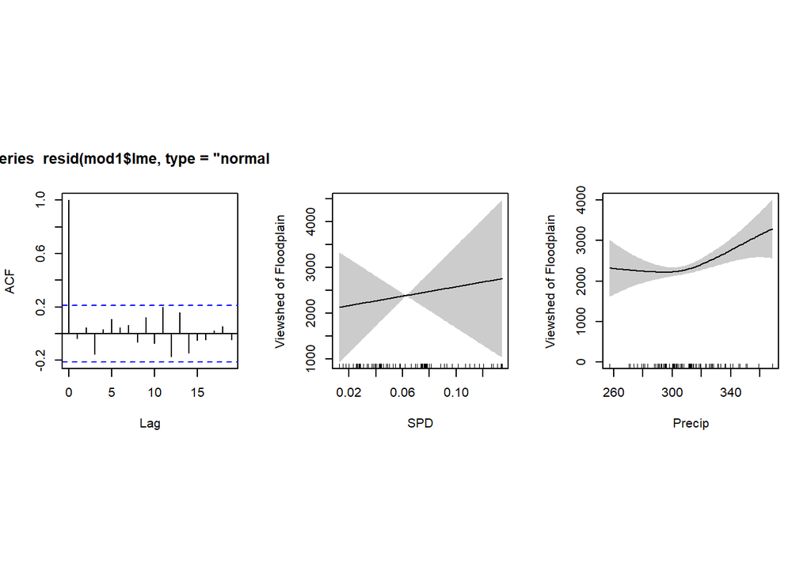

```r
#hist(resid(mod1$gam),main="NumStor~SPD+AvgPrecip")
acf(resid(mod1$lme,type="normalized"))
#plot(mod1$gam,select=1,shade=T,residuals=T,ylab="VS",xlab="Average Precip",shift= ilink(coef(mod1$gam)[1]))
#plot(mod1$gam,select=2,shade=T,residuals=T,ylab="vS",xlab="SPD",shift= ilink(coef(mod1$gam)[1]))
plot(mod1$gam,select=2,shade=T,ylab="Viewshed of Floodplain",xlab="SPD",shift= coef(mod1$gam)[1]);box()

plot(mod1$gam,select=1,shade=T,ylab="Viewshed of Floodplain",xlab="Precip",shift= coef(mod1$gam)[1],ylim=c(0,4000));box()
```

```r
#,ylim=c(0,4000)
###
#deviance explained
mod0<-gam(VS~1,data=df)
 DN <- sum(residuals(mod0, type = "pearson")^2) # Deviance from NULL GAMM
 DR <- sum(residuals(mod1$gam, type = "pearson")^2) # Deviance from our GAMM
 DE <- (DN-DR)*100/DN; DE # Deviance Explained from our GAMM model
```

```
## [1] 91.3625
```

```r
#residuals
hist(residuals(mod1$lme,
              type="normalized"),
    main=NA,
    xlab="Residuals",
    col="grey")

#dispersion
resid.ssq <- sum(residuals(mod1$lme,type="pearson")^2)        ## sum of squares of Pearson resids
resid.df <- summary(mod1$gam)$n - length(coef(mod1$lme))  ## estimated resid df (N-p), or gam.fish$gam$df.residual
resid.ssq/resid.df
```

```
## [1] 1.226204
```

```r
#underfitting
k.check(mod1$gam)
```

```
##              k'    edf  k-index p-value
## s(avgprecip)  9 2.2025 0.832473    0.06
## s(spd)        9 1.0000 0.507807    0.00
```

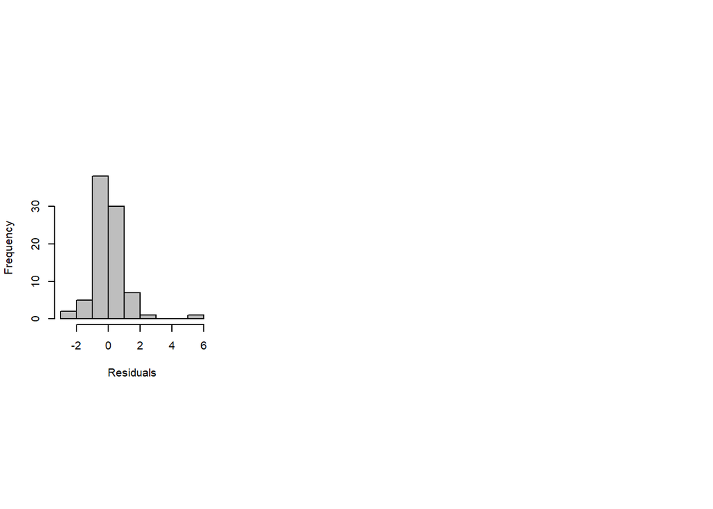

```r
########################################################################
#################
#ElevFP
#mod1<-gam(elevfp~s(avgprecip)+s(spd,k=2)+s(meanGDE),data=df)
#summary(mod1)
#hist(residuals(mod1))
#acf(resid(mod1),lag.max=1000)
par(pty="s")
par(mfrow=c(1,3))
```

```r
#gamm
mod1<-gamm(elevfp~s(avgprecip)+s(spd)+aors,data=df,correlation=corAR1())
summary(mod1$gam)
```

```
##
## Family: gaussian
## Link function: identity
##
## Formula:
## elevfp ~ s(avgprecip) + s(spd) + aors
##
## Parametric coefficients:
##             Estimate Std. Error t value Pr(>|t|)
## (Intercept)   44.531      2.403  18.529   <2e-16 ***
## aors          -2.779      2.628  -1.058    0.291
## ---
## Signif. codes:  0 '***' 0.001 '**' 0.01 '*' 0.05 '.' 0.1 ' ' 1
##
## Approximate significance of smooth terms:
##                edf Ref.df      F  p-value
## s(avgprecip) 1.831  1.831  5.103   0.0308 *
## s(spd)       4.733  4.733 13.094 2.38e-11 ***
## ---
## Signif. codes:  0 '***' 0.001 '**' 0.01 '*' 0.05 '.' 0.1 ' ' 1
##
## R-sq.(adj) =  0.582
##   Scale est. = 80.296    n = 839
```

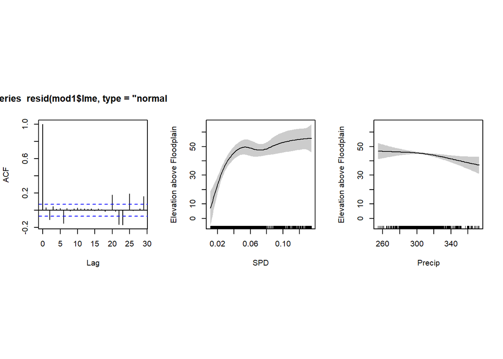

```r
#hist(resid(mod1$gam),main="NumStor~SPD+AvgPrecip")
acf(resid(mod1$lme,type="normalized"))
#plot(mod1$gam,select=1,shade=T,residuals=T,ylab="Elev Above FP",xlab="Average Precip",shift= ilink(coef(mod1$gam)[1]))
#plot(mod1$gam,select=2,shade=T,residuals=T,ylab="Elev Above FP",xlab="SPD",shift= ilink(coef(mod1$gam)[1]))
plot(mod1$gam,select=2,shade=T,ylab="Elevation above Floodplain",xlab="SPD",shift= coef(mod1$gam)[1]);box() #this plot is close but not exact...
plot(mod1$gam,select=1,shade=T,ylab="Elevation above Floodplain",xlab="Precip",shift= coef(mod1$gam)[1]);box() #this plot
```

```r
###
#deviance explained
mod0<-gam(elevfp~1,data=df)
 DN <- sum(residuals(mod0, type = "pearson")^2) # Deviance from NULL GAMM
 DR <- sum(residuals(mod1$gam, type = "pearson")^2) # Deviance from our GAMM
 DE <- (DN-DR)*100/DN; DE # Deviance Explained from our GAMM model
```

```
## [1] 58.55856
```

```r
#residuals
hist(residuals(mod1$lme,
              type="normalized"),
    main=NA,
    xlab="Residuals",
    col="grey")

#dispersion
resid.ssq <- sum(residuals(mod1$lme,type="pearson")^2)        ## sum of squares of Pearson resids
resid.df <- summary(mod1$gam)$n - length(coef(mod1$lme))  ## estimated resid df (N-p), or gam.fish$gam$df.residual
resid.ssq/resid.df
```

```
## [1] 0.9397157
```

```r
#underfitting
k.check(mod1$gam)
```

```
##              k'      edf   k-index p-value
## s(avgprecip)  9 1.831324 0.9315241  0.0275
## s(spd)        9 4.732999 0.6905600  0.0000
```

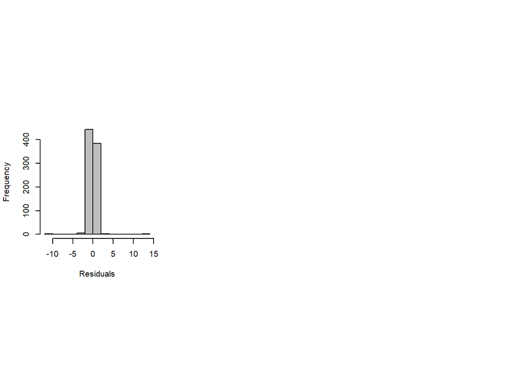

## Results!

I mean, maybe it’s during periods when agricultural productivity is high that populations are expanding and occupying into lower ranked habitats. During these good periods, people are building more storage features as a way of dividing their crop into more dice rolls and placing these storage features in more inaccessible locations. If so, this would be risk adverse behavior!

Alternatively, movement into lower ranked habitats could also result in an increase risk of loss due to theft (possibly as a result of inequality stemming from despotic exclusion from habitats) in the environment and people reacting by upping their investment in storage by building more and making them more difficult to access.

### Number of storage

More storage when people occupy lower ranked habitats independent of population. What would the occupation of lower ranked habitats mean? 1. Higher population densities (which are accounted for in the model already), 2. In IFD everyone is doing the same, but in IDD some habitats may retain a higher suitability as a function of despotic actions. Perhaps this is a result of IDD processes?

### VS and Elevation

One explanation is that when lower ranked habitats were occupied Fremont were both increasing the difficulty to access and the viewshed of a storage feature. This would imply monitoring, but monitoring also requires vigilance.

Another explanation is that they were increasing difficulty of access or VS and the increase in the other is just a by product. I think that increasing the difficulty of access is likely the answer here, considering the cryptic nature of some storage features.

## NMC Storage Strategy

I kind of think its just a response to increasing populations and potential thieving and people are reacting by making their storage features harder to access by placing them higher off the floodplain and perhaps dividing their crops among more storage features.